# Pooled 3-Cohort Neuropsych Data Preparation and QC

### 6.4 Save pooled availability heatmaps

```r
availability_test_order <- availability_support_pooled |>
  distinct(
    xprize_subdomain,
    test
  ) |>
  arrange(
    xprize_subdomain,
    test
  )

walk2(
  availability_test_order$xprize_subdomain,
  availability_test_order$test,
  \(subdomain_x, test_x) {

    plot_x <- plot_followup_availability_one_test(
      data_x = availability_support_pooled,
      test_x = test_x
    )

    subdomain_file_x <- subdomain_x |>
      str_to_lower() |>
      str_replace_all("&", "and") |>
      str_replace_all("[^a-z0-9]+", "_") |>
      str_replace_all("_+", "_") |>
      str_replace_all("^_|_$", "")

    test_file_x <- test_x |>
      str_to_lower() |>
      str_replace_all("[^a-z0-9]+", "_") |>
      str_replace_all("_+", "_") |>
      str_replace_all("^_|_$", "")

    ggsave(
      filename = file.path(
        qc_plots_dir,
        paste0(
          "pooled3_followup_availability_baselineage_",
          subdomain_file_x,
          "_",
          test_file_x,
          "_",
          output_suffix,
          ".pdf"
        )
      ),
      plot = plot_x,
      width = 12,
      height = 5
    )
  }
)
```

## 7. Empirical age coverage for Class 1 age-as-time models

This section summarizes empirical age coverage for the Class 1 age-as-time models.

The Class 1 models estimate cognitive performance as a function of age at measurement. Therefore, the main QC question is whether each test has enough observations across the observed and target age ranges.

Unlike Section 6, this QC does not use baseline age × follow-up horizons. Instead, it summarizes observed neuropsychological measurements by age-at-measure category.

### 7.1 Prepare observed age categories

```r
age_measure_breaks <- c(
  -Inf, 30, 35, 40, 45, 50, 55, 60, 65, 70, 75, 80, 85, 90, Inf
)

age_measure_levels <- c(
  "<30",
  "30-34",
  "35-39",
  "40-44",
  "45-49",
  "50-54",
  "55-59",
  "60-64",
  "65-69",
  "70-74",
  "75-79",
  "80-84",
  "85-89",
  ">=90"
)
```

```r
class1_age_level <- model_ready_pool |>
  left_join(
    test_subdomain_map,
    by = "test"
  ) |>
  mutate(
    age_measure_bin = cut(
      age_at_measure,
      breaks = age_measure_breaks,
      labels = age_measure_levels,
      right = FALSE
    ),
    age_measure_bin = factor(
      age_measure_bin,
      levels = age_measure_levels
    )
  ) |>
  filter(
    !is.na(age_measure_bin)
  )

class1_age_level |>
  count(
    age_measure_bin
  ) |>
  arrange(
    age_measure_bin
  ) |>
  knitr::kable()
```

| age_measure_bin | n |
| --- | --- |
| <30 | 621 |
| 30-34 | 1895 |
| 35-39 | 3955 |
| 40-44 | 7190 |
| 45-49 | 11967 |
| 50-54 | 16469 |
| 55-59 | 19467 |
| 60-64 | 19930 |
| 65-69 | 20261 |
| 70-74 | 19041 |
| 75-79 | 17854 |
| 80-84 | 18183 |
| 85-89 | 15630 |
| >=90 | 9230 |

### 7.2 Create Class 1 age coverage table

```r
class1_age_coverage <- class1_age_level |>
  group_by(
    test,
    xprize_subdomain,
    idtype_label,
    sex_label,
    age_measure_bin
  ) |>
  summarise(
    n_obs = n(),
    n_subjects = n_distinct(dbgap_subject_id),
    .groups = "drop"
  ) |>
  group_by(
    test,
    xprize_subdomain,
    idtype_label,
    sex_label
  ) |>
  complete(
    age_measure_bin = factor(
      age_measure_levels,
      levels = age_measure_levels
    ),
    fill = list(
      n_obs = 0,
      n_subjects = 0
    )
  ) |>
  ungroup() |>
  mutate(
    idtype_label = factor(
      idtype_label,
      levels = c(
        "Original",
        "Offspring",
        "Gen3"
      )
    )
  ) |>
  arrange(
    test,
    sex_label,
    age_measure_bin,
    idtype_label
  )
```

```r
class1_age_coverage |>
  filter(
    test == "lmi"
  ) |>
  group_by(
    test,
    sex_label,
    age_measure_bin
  ) |>
  summarise(
    n_obs_total = sum(n_obs),
    n_subjects_total = sum(n_subjects),
    .groups = "drop"
  ) |>
  knitr::kable()
```

| test | sex_label | age_measure_bin | n_obs_total | n_subjects_total |
| --- | --- | --- | --- | --- |
| lmi | Women | <30 | 26 | 26 |
| lmi | Women | 30-34 | 75 | 75 |
| lmi | Women | 35-39 | 166 | 165 |
| lmi | Women | 40-44 | 301 | 299 |
| lmi | Women | 45-49 | 481 | 472 |
| lmi | Women | 50-54 | 733 | 700 |
| lmi | Women | 55-59 | 871 | 826 |
| lmi | Women | 60-64 | 856 | 792 |
| lmi | Women | 65-69 | 909 | 825 |
| lmi | Women | 70-74 | 832 | 734 |
| lmi | Women | 75-79 | 852 | 680 |
| lmi | Women | 80-84 | 974 | 662 |
| lmi | Women | 85-89 | 964 | 579 |
| lmi | Women | >=90 | 662 | 352 |
| lmi | Men | <30 | 18 | 18 |
| lmi | Men | 30-34 | 61 | 61 |
| lmi | Men | 35-39 | 125 | 125 |
| lmi | Men | 40-44 | 236 | 236 |
| lmi | Men | 45-49 | 453 | 446 |
| lmi | Men | 50-54 | 607 | 595 |
| lmi | Men | 55-59 | 730 | 692 |
| lmi | Men | 60-64 | 777 | 721 |
| lmi | Men | 65-69 | 775 | 693 |
| lmi | Men | 70-74 | 791 | 714 |
| lmi | Men | 75-79 | 732 | 593 |
| lmi | Men | 80-84 | 673 | 462 |
| lmi | Men | 85-89 | 502 | 291 |
| lmi | Men | >=90 | 230 | 126 |

```r
write_csv(
  class1_age_coverage,
  file.path(
    qc_table_dir,
    make_output_name("pooled3_class1_age_coverage_pooled", "csv")
  )
)
```

### 7.3 Define plotting function for one test

```r
plot_class1_age_coverage_one_test <- function(data_x, test_x) {

  data_sub <- data_x |>
    filter(
      test == test_x
    )

  subdomain_x <- data_sub |>
    distinct(xprize_subdomain) |>
    pull(xprize_subdomain) |>
    first()

  label_data <- data_sub |>
    group_by(
      sex_label,
      age_measure_bin
    ) |>
    summarise(
      n_obs_total = sum(n_obs),
      .groups = "drop"
    )

  ggplot(
    data_sub,
    aes(
      x = age_measure_bin,
      y = n_obs,
      fill = idtype_label
    )
  ) +
    geom_col(
      width = 0.75,
      color = "white",
      linewidth = 0.25
    ) +
    geom_text(
      data = label_data,
      aes(
        x = age_measure_bin,
        y = n_obs_total,
        label = n_obs_total
      ),
      inherit.aes = FALSE,
      vjust = -0.25,
      size = 2.8,
      color = "grey40"
    ) +
    facet_wrap(
      vars(sex_label),
      nrow = 1
    ) +
    scale_fill_jama(
      name = "Cohort"
    ) +
    scale_y_continuous(
      expand = expansion(mult = c(0, 0.12))
    ) +
    labs(
      title = paste0(
        "Observed age coverage for Class 1 model: ",
        test_x
      ),
      subtitle = paste0(
        "X-Prize subdomain: ",
        subdomain_x
      ),
      x = "Age at measurement category (years)",
      y = "Number of observations"
    ) +
    theme_bw(base_size = 12) +
    theme(
      legend.position = "bottom",
      plot.title = element_text(size = 15, face = "bold"),
      plot.subtitle = element_text(size = 12, color = "grey30"),
      axis.title = element_text(size = 13),
      axis.text = element_text(size = 10.5),
      axis.text.x = element_text(angle = 45, hjust = 1),
      strip.background = element_rect(fill = "grey90"),
      strip.text = element_text(size = 11),
      panel.grid.minor = element_blank(),
      panel.spacing.x = unit(0.8, "lines")
    )
}
```

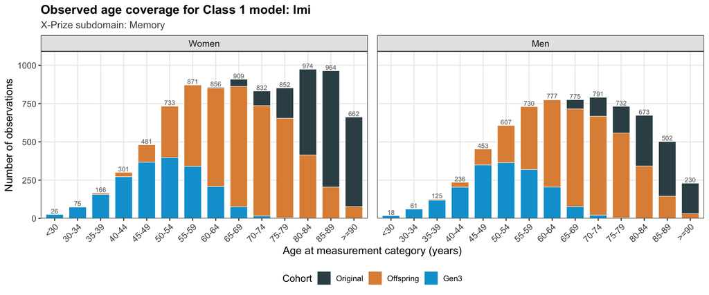

```r
plot_class1_age_coverage_one_test(
  data_x = class1_age_coverage,
  test_x = "lmi"
)
```

### 7.4 Save Class 1 age coverage plots by test

```r
class1_test_order <- class1_age_coverage |>
  distinct(
    xprize_subdomain,
    test
  ) |>
  arrange(
    xprize_subdomain,
    test
  )

walk2(
  class1_test_order$xprize_subdomain,
  class1_test_order$test,
  \(subdomain_x, test_x) {

    plot_x <- plot_class1_age_coverage_one_test(
      data_x = class1_age_coverage,
      test_x = test_x
    )

    subdomain_file_x <- subdomain_x |>
      str_to_lower() |>
      str_replace_all("&", "and") |>
      str_replace_all("[^a-z0-9]+", "_") |>
      str_replace_all("_+", "_") |>
      str_replace_all("^_|_$", "")

    test_file_x <- test_x |>
      str_to_lower() |>
      str_replace_all("[^a-z0-9]+", "_") |>
      str_replace_all("_+", "_") |>
      str_replace_all("^_|_$", "")

    ggsave(
      filename = file.path(
        qc_plots_dir,
        paste0(
          "pooled3_class1_age_coverage_",
          subdomain_file_x,
          "_",
          test_file_x,
          "_",
          output_suffix,
          ".pdf"
        )
      ),
      plot = plot_x,
      width = 12,
      height = 5
    )
  }
)
```